# DHIS2 Metadata Assessment

DHIS2 Implementation Team

2021-11-11

# Target server: https://gmdhmis.dhis2.org/staging/

## Metadata issues

|  | Theme | Issue | Level | Count | Percentage | Details |
| --- | --- | --- | --- | --- | --- | --- |
| 1 | Categories | Categories without category options | Warning | 2 | 4% | Details |
| 2 | Categories | Category options with no categories | Warning | 1 | 1% | Details |
| 3 | Categories | Additional default category option combos based on category option. | Critical | 0 | 0% | Details |
| 4 | Categories | Category option combinations with incorrect cardnality. | Severe | 2 | 1% | Details |
| 5 | Charts | Charts that have not been opened in the last 12 months | Warning | 1097 | 100% | Details |
| 6 | Dashboards | Total number of dashboards | Info | 362 | 100% | Details |
| 7 | Dashboards | Dashboards that have been viewed 1 time or less in the past three years | Warning | 325 | 89% | Details |
| 8 | Dashboards | Dashboards that have not been opened in the last 12 months | Warning | 352 | 97% | Details |
| 9 | Dashboards | Dashboards with no content | Info | 139 | 38% | Details |
| 10 | Data elements (aggregate) | Total count of aggregate data elements | Info | 3277 | 100% | Details |

[output cut: 30 more lines]

## Users

- Total users: 772
- Total disabled users: 27
- Total users logged in within 7 days: 2
- Total users logged in within 30 days: 6
- Total users logged in within 90 days: 9
- Total users logged in within a year: 29
- Users who have never logged in: 24
- Percentage of users who are disabled: 3 %
- Number of users who have superuser: 25
- Percentage of users who have superuser: 3 %

### Distribution of last user logins

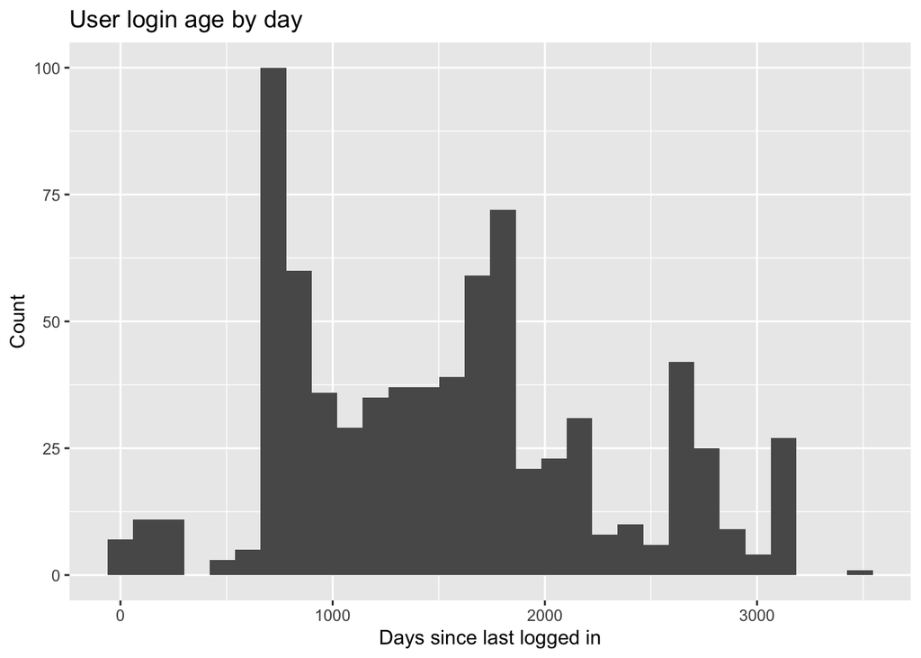

### Distribution of users within the hierarchy

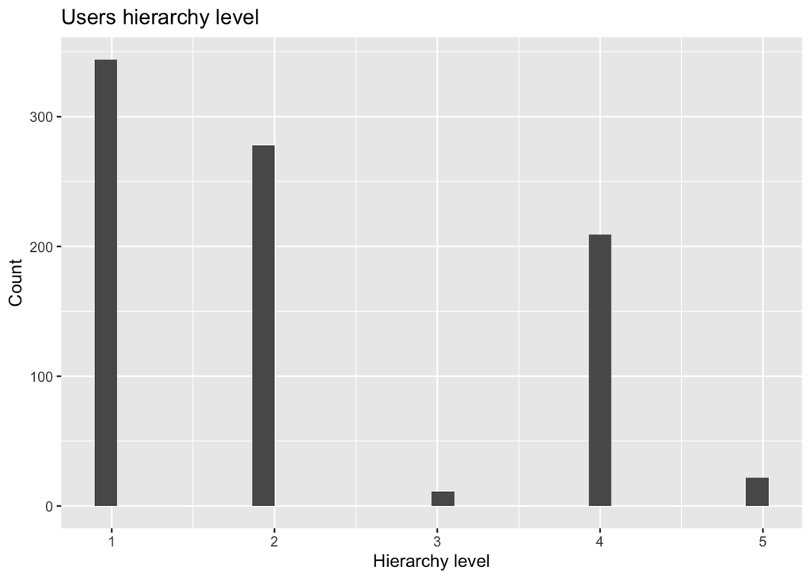

## Guidance section

This section of the report contains guidance information which provide more context and expiation of each of the checks.

## Categories

### Categories without category options

Level: Warning

Issue count: 2 (4%)

**Recommendation**

Any categories without category options should either be removed from the system if they are not in use. Otherwise, appropriate category options should be added to the category.

[Details](https://gmdhmis.dhis2.org/staging/api/sqlViews/QOI2PBHvksS/data.csv)

### Category options with no categories

Level: Warning

Issue count: 1 (1%)

**Recommendation**

Category options which are not part of any category should be removed or alternatively should be added to an appropriate category.

[Details](https://gmdhmis.dhis2.org/staging/api/sqlViews/Fp9jUG2txCV/data.csv)

### Additional default category option combos based on category option.

Level: Critical

Issue count: 0 (0%)

**Recommendation**

All references to the additional default category option combination should be replaced with the desired default category option combination.

[Details](https://gmdhmis.dhis2.org/staging/api/sqlViews/dymvZMsbw9D/data.csv)

### Category option combinations with incorrect cardnality.

Level: Severe

Issue count: 2 (1%)

**Recommendation**

Category option combinations which have an incorrect cardinality will be ignored by the DHIS2 analytics system and should be removed.

[Details](https://gmdhmis.dhis2.org/staging/api/sqlViews/ZMsFbuKljqn/data.csv)

## Charts

### Charts that have not been opened in the last 12 months

Level: Warning

Issue count: 1097 (100%)

**Recommendation**

[Details](https://gmdhmis.dhis2.org/staging/api/sqlViews/nxpcGQ7h4ey/data.csv)

## Dashboards

### Total number of dashboards

Level: Info

Issue count: 362 (100%)

**Recommendation**

DHIS2 should contain useful dashboards for users.

[Details](https://gmdhmis.dhis2.org/staging/api/sqlViews/WAgKp3hIWzF/data.csv)

### Dashboards that have been viewed 1 time or less in the past three years

Level: Warning

Issue count: 325 (89%)

**Recommendation**

[Details](https://gmdhmis.dhis2.org/staging/api/sqlViews/Dfjw69AKQln/data.csv)

### Dashboards that have not been opened in the last 12 months

Level: Warning

Issue count: 352 (97%)

**Recommendation**

Dashboards that should be reviewed routinely and are not point to a broader data use issue that will not be addressed by technical means. Such dashboards may need to be kept while a process for reviewing them more frequently becomes more well defined.

[Details](https://gmdhmis.dhis2.org/staging/api/sqlViews/dEwPGTpXYY2/data.csv)

### Dashboards with no content

Level: Info

Issue count: 139 (38%)

**Recommendation**

Dashboards without content that have not been modified in the last 14 days can be removed.

[Details](https://gmdhmis.dhis2.org/staging/api/sqlViews/NMZhvSZpTtW/data.csv)

## Data elements (aggregate)

### Total count of aggregate data elements

Level: Info

Issue count: 3277 (100%)

**Recommendation**

DHIS2 should contain useful data elements for users.

[Details](https://gmdhmis.dhis2.org/staging/api/sqlViews/SvH33Yk0iQM/data.csv)

### Aggregate data elements not used in any favourites (directly or through indicators)

Level: Warning

Issue count: 2038 (62%)

**Recommendation**

Data elements that are not routinely being reviewed in analysis, either directly or indirectly through indicators, should be reviewed to determine if they still need to be collected. If these are meant to be used in routine review, then associated outputs should be created using them. If these data elements are not going to be used for any type of information review, consideration should be made to either archive them or delete them.

[Details](https://gmdhmis.dhis2.org/staging/api/sqlViews/EFyNHwRu9w8/data.csv)

### Aggregate data elements assigned to 1 or less orgunit

Level: Warning

Issue count: 694 (21%)

**Recommendation**

If the dataset is active, then review the organisation unit assignments. If the dataset is not active, then it should be removed from the system.

[Details](https://gmdhmis.dhis2.org/staging/api/sqlViews/xdx9XquVi30/data.csv)

### Aggregate data elements not in any data element groups.

Level: Warning

Issue count: 450 (13%)

**Recommendation**

Data elements that are not in a data element group should be added to a relevant data element group. If the data elements are not needed, they should be deleted.

[Details](https://gmdhmis.dhis2.org/staging/api/sqlViews/bOxvtqRYGXh/data.csv)

### Aggregate data elements that have not been changed in last 100 days and do not have any data values

Level: Warning

Issue count: 902 (27%)

**Recommendation**

Data elements that have no data associated with them and which there are no plans to start using for data collection should be deleted.

[Details](https://gmdhmis.dhis2.org/staging/api/sqlViews/eBfvtecrvqU/data.csv)

### Aggregate data elements with NO data values

Level: Warning

Issue count: 904 (27%)

**Recommendation**

Consider removing data elements with no data values.

[Details](https://gmdhmis.dhis2.org/staging/api/sqlViews/MzPQlUsApVO/data.csv)

### Aggregate data elements with no data values in the last 3 periods (based on data set period type).

Level: Warning

Issue count: 3265 (99%)

**Recommendation**

[Details](https://gmdhmis.dhis2.org/staging/api/sqlViews/W7GMsAf31cR/data.csv)

## Data elements (tracker)

### Total count of tracker data elements

Level: Info

Issue count: 528 (100%)

**Recommendation**

DHIS2 should contain useful data elements for users.

[Details](https://gmdhmis.dhis2.org/staging/api/sqlViews/cDyPCWYPhYN/data.csv)

### Tracker data elements not in any data element groups.

Level: Warning

Issue count: 414 (78%)

**Recommendation**

Data elements that are not in a data element group should be added to a relevant data element group. If the data elements are not needed, they should be deleted.

[Details](https://gmdhmis.dhis2.org/staging/api/sqlViews/hFgm57sWTqR/data.csv)

## Datasets

### Total number of data sets

Level: Info

Issue count: 64 (100%)

**Recommendation**

DHIS2 should contain datasets which are useful for data entry.

[Details](https://gmdhmis.dhis2.org/staging/api/sqlViews/Ijyn3sXlmgw/data.csv)

### Data sets that have not been changed in last 100 days and are assigned to 1 or less orgunits

Level: Warning

Issue count: 16 (25%)

**Recommendation**

Datasets which are not active should be removed from the system to decrease system clutter and metadata size.

[Details](https://gmdhmis.dhis2.org/staging/api/sqlViews/Uj63Zrxixeq/data.csv)

### Data sets with no data values in the last 3 periods (based on data set period type).

Level: Warning

Issue count: 57 (89%)

**Recommendation**

- If a data set is not being updated with new data or no new data values are being entered within the last 3 periods (relative to the period type assigned to the dataset ex. monthly will be the last 3 months, quarterly the last 3 quarters) against the dataset but there are data values from previous periods the data set should be archived (ie. assign it a prefix)
- If a data set has no new or previous data values within the last 3 periods (relative to the period type assigned to the dataset) and will not be used to collect data, the data set should be removed.

[Details](https://gmdhmis.dhis2.org/staging/api/sqlViews/N4z01NXIcir/data.csv)

### Dataset sections with non-sequential sort order

Level: Warning

Issue count: 103 (90%)

**Recommendation**

[Details](https://gmdhmis.dhis2.org/staging/api/sqlViews/UCdK7FmUvp4/data.csv)

## General

### Object names which have leading spaces

Level: Warning

Issue count: 44 (-)

**Recommendation**

[Details](https://gmdhmis.dhis2.org/staging/api/sqlViews/FCBp1MzbFN8/data.csv)

### Object names which have trailing spaces

Level: Warning

Issue count: 428 (-)

**Recommendation**

[Details](https://gmdhmis.dhis2.org/staging/api/sqlViews/uZSG2nDJyCM/data.csv)

### Object names which have multiple spaces

Level: Warning

Issue count: 767 (-)

**Recommendation**

[Details](https://gmdhmis.dhis2.org/staging/api/sqlViews/evDSyoZdiIH/data.csv)

## Indicators

### Total count of indicators

Level: Info

Issue count: 751 (100%)

**Recommendation**

DHIS2 should contain useful indicators for users.

[Details](https://gmdhmis.dhis2.org/staging/api/sqlViews/IY6j3BNM2nG/data.csv)

### Indicators not in any groups

Level: Warning

Issue count: 146 (19%)

**Recommendation**

Indicators that are not in a indicator group should be added to a relevant indicator group. If the indicators are not needed, they should be deleted.

[Details](https://gmdhmis.dhis2.org/staging/api/sqlViews/Is7g6eFibfG/data.csv)

### Indicators not used in favourites OR data sets

Level: Warning

Issue count: 210 (27%)

**Recommendation**

Indicators that are not routinely being reviewed in analysis, either in an output or data set, should be reviewed to determine if they still need to be calculated. If these are meant to be used for routine review, then associated outputs should be created using them. If these indicators are not going to be used for any type of information review, consideration should be made to either archive them or delete them.

[Details](https://gmdhmis.dhis2.org/staging/api/sqlViews/wnQsTWqfpdV/data.csv)

### Indicators not used in favourites

Level: Warning

Issue count: 325 (43%)

**Recommendation**

Indicators that are not routinely being reviewed in analysis, either in an output or data set, should be reviewed to determine if they still need to be calculated. If these are meant to be used for routine review, then associated outputs should be created using them. If these indicators are not going to be used for any type of information review, consideration should be made to either archive them or delete them.

[Details](https://gmdhmis.dhis2.org/staging/api/sqlViews/zqKrnvP2CMp/data.csv)

## Option sets

### Unused option sets

Level: Warning

Issue count: 10 (11%)

**Recommendation**

Consider deleting unused option sets, or alternatively, ensure that they have been properly assigned.

[Details](https://gmdhmis.dhis2.org/staging/api/sqlViews/i4OtFbZmqkp/data.csv)

### Option sets with incorrect sort order

Level: Severe

Issue count: 1 (1%)

**Recommendation**

If it is possible to open the option set in the maintenance app, you can resort the option set, which should correct the problem. Another possible solution is to directly update the sort_order property of in the optionset table in the database, ensuring that a valid sequence is present for all options in the option set.

[Details](https://gmdhmis.dhis2.org/staging/api/sqlViews/NxtEkZcmLl0/data.csv)

### Empty option sets

Level: Warning

Issue count: 2 (2%)

**Recommendation**

Options should either be added to the option set, or the option set should be deleted.

[Details](https://gmdhmis.dhis2.org/staging/api/sqlViews/wjIQ26nrXT8/data.csv)

## Organisation units

### Orgunits that are not in all compulsory orgunit group sets

Level: Severe

Issue count: 0 (0%)

**Recommendation**

Add all organization units to exactly one group within a compulsory organization unit group.

[Details](https://gmdhmis.dhis2.org/staging/api/sqlViews/HnmKIwXFWy5/data.csv)

### Organisation units which have an opening date later than the closed date.

Level: Severe

Issue count: 0 (0%)

**Recommendation**

Alter either the opening or closing date of all affected organisation units so that the closing date is after the opening date.

[Details](https://gmdhmis.dhis2.org/staging/api/sqlViews/qGXxCOoeipq/data.csv)

### Organisation units should not have trailing spaces

Level: Warning

Issue count: 58 (4%)

**Recommendation**

If the number of affected organisation units is small, the easiest remedy is to correct them directly from the user interface. Another possible option would be to replace all of the multiple spaces using SQL.

[Details](https://gmdhmis.dhis2.org/staging/api/sqlViews/N2qHFwW0Yyr/data.csv)

### Point coordinates which are not contained by their parent

Level: Warning

Issue count: 16 (4%)

**Recommendation**

Often boundary files are simplified when they are uploaded into DHIS2. This process may result in facilities which are located close to the border of a given district to fall outside of the district when the boundary is simplified. This is considered to be more of a cosmetic problem for most DHIS2 installations, but could become an issue if any geospatial analysis is attempted using the boundaries and point coordinates. In cases where the facility falls outside of its parent’s boundary you should confirm that the coordinates are correct. If the location is close to the boundary, you may want to reconsider how the boundary files have been simplified. Otherwise, if the location of the facility is completely incorrect, it should be rectified.

[Details](https://gmdhmis.dhis2.org/staging/api/sqlViews/QC6yuqSTQXa/data.csv)

### Organisation units close to Null Island

Level: Severe

Issue count: 0 (0%)

**Recommendation**

Update the coordinates of the affected organisation unit to the correct location.

[Details](https://gmdhmis.dhis2.org/staging/api/sqlViews/yBAsnuFkmbj/data.csv)

### Organisation units should not have multiple spaces in their names

Level: Warning

Issue count: 46 (3%)

**Recommendation**

If the number of affected organisation units is small, the easiest remedy is to correct them directly from the user interface. Another possible option would be to replace all of the multiple spaces using SQL.

[Details](https://gmdhmis.dhis2.org/staging/api/sqlViews/spwhfsg5Kkn/data.csv)

### Organisation units with invalid geometry

Level: Critical

Issue count: 3 (1%)

**Recommendation**

Update the geometry of the affected organisation units to a valid geometry. It may be possible to use the PostGIS function `ST_MakeValid` to automatically fix the problem. However, in other cases the geometry may need to be edited in a GIS tool, and then updated again in DHIS2.

[Details](https://gmdhmis.dhis2.org/staging/api/sqlViews/lEmJf83tdNR/data.csv)

### Organisation hierarchy should have a single root

Level: Critical

Issue count: 0 (0%)

**Recommendation**

[Details](https://gmdhmis.dhis2.org/staging/api/sqlViews/CVy8mwGN6Ec/data.csv)